# Quality control and PCA for FLC1 RNA-seq

Edward Wallace

2024-12-04

# Summary

Quality control of RNA-seq data after read processing.

This analysis does:

- Scatter plot of counts showing log-scale correlations
- PCA plot showing how samples are similar to one another

It concludes that:

- Replicates group together in PCA space, so the experiment is reproducible
- PC1 contrasts WT with FLC1delta, capturing about 65% of variance
- PC2 contrasts temperature (for WT) and EGTA treatment (more for FLC1delta)
- There is a lot more to be understood here.

# Load and organise raw count data

## Load the raw counts

```r
counts_raw <-
  here::here("results", "counts", "counts.txt") %>%
  readr::read_tsv(comment = "#")
counts_raw
```

```
## # A tibble: 6,795 × 36
##    Geneid       Chr Start   End Strand Length `11308_9_S9_R2_001_aln.bam`
##    <chr>      <dbl> <dbl> <dbl> <chr>   <dbl>                       <dbl>
##  1 CNAG_00002     1 12730 13756 +        1027                         304
##  2 CNAG_00003     1 14025 16421 -        2397                          32
##  3 CNAG_00004     1 16427 19850 -        3424                          90
##  4 CNAG_00005     1 20750 22911 -        2162                         566
##  5 CNAG_00006     1 24710 26159 -        1450                        1355
##  6 CNAG_00007     1 26275 28568 +        2294                         536
##  7 CNAG_00008     1 28555 32905 -        4351                         224
##  8 CNAG_00009     1 33086 34879 +        1794                         193
##  9 CNAG_00010     1 35746 39624 -        3879                         198
## 10 CNAG_00011     1 40231 42267 +        2037                         129
## # ℹ 6,785 more rows
## # ℹ 29 more variables: `11308_14_S14_R2_001_aln.bam` <dbl>,
## #   `11308_4_S4_R2_001_aln.bam` <dbl>, `11308_6_S6_R2_001_aln.bam` <dbl>,
## #   `11308_7_S7_R2_001_aln.bam` <dbl>, `11308_17_S17_R2_001_aln.bam` <dbl>,
## #   `11308_5_S5_R2_001_aln.bam` <dbl>, `11308_27_S27_R2_001_aln.bam` <dbl>,
## #   `11308_22_S22_R2_001_aln.bam` <dbl>, `11308_8_S8_R2_001_aln.bam` <dbl>,
## #   `11308_10_S10_R2_001_aln.bam` <dbl>, `11308_24_S24_R2_001_aln.bam` <dbl>, …
```

## Load the sample sheet

```r
sample_sheet <-
  here::here("input", "experiment",
             "CryptoRNAseqFLC1SampleKey.csv") %>%
  readr::read_csv(comment = "#", col_types = "ccccccc") %>%
  dplyr::mutate(Condition = stringr::str_sub(SampleName,start = 1L, end = -3L))

sample_sheet
```

```
## # A tibble: 30 × 8
##    SampleID Temperature Media BioRep Strain     SampleName FLC1  Condition
##    <chr>    <chr>       <chr> <chr>  <chr>      <chr>      <chr> <chr>
##  1 1        30          YPD   1      "KN99_"    WT_30_Y_1  WT    WT_30_Y
##  2 2        30          YPD   2      "KN99_"    WT_30_Y_2  WT    WT_30_Y
##  3 3        30          YPD   3      "KN99_"    WT_30_Y_3  WT    WT_30_Y
##  4 4        30          YPD   1      "flc1\xc6" FL_30_Y_1  delta FL_30_Y
##  5 5        30          YPD   2      "flc1\xc6" FL_30_Y_2  delta FL_30_Y
##  6 6        30          YPD   3      "flc1\xc6" FL_30_Y_3  delta FL_30_Y
##  7 7        37          YPD   1      "KN99_"    WT_37_Y_1  WT    WT_37_Y
##  8 8        37          YPD   2      "KN99_"    WT_37_Y_2  WT    WT_37_Y
##  9 9        37          YPD   3      "KN99_"    WT_37_Y_3  WT    WT_37_Y
## 10 10       37          YPD   1      "flc1\xc6" FL_37_Y_1  delta FL_37_Y
## # ℹ 20 more rows
```

## Organise the counts using the sample sheet

```r
counts_all <-
  counts_raw %>%
  dplyr::rename_with(stringr::word,
                     start = 2L, sep = fixed("_"), .cols = ends_with(".bam")) %>%
  dplyr::select(sample_sheet$SampleID)  %>%
  magrittr::set_colnames(sample_sheet$SampleName)  %>%
  magrittr::set_rownames(counts_raw$Geneid)
counts_all
```

```
## # A tibble: 6,795 × 30
##    WT_30_Y_1 WT_30_Y_2 WT_30_Y_3 FL_30_Y_1 FL_30_Y_2 FL_30_Y_3 WT_37_Y_1
##  *     <dbl>     <dbl>     <dbl>     <dbl>     <dbl>     <dbl>     <dbl>
##  1       322       378       346       310       309       174       396
##  2        19        43        27        54        52        33        41
##  3        94        80        83       102        94        65       100
##  4       462       399       385       378       344       310       534
##  5      1019      1533      1256      1505      1359       778      1684
##  6       471       703       579       476       407       284       658
##  7       141       226       206       272       259       164       278
##  8       160       162       187       323       250       171       231
##  9       195       199       242       362       272       159       369
## 10        85       117       114       162       139        81       194
## # ℹ 6,785 more rows
## # ℹ 23 more variables: WT_37_Y_2 <dbl>, WT_37_Y_3 <dbl>, FL_37_Y_1 <dbl>,
## #   FL_37_Y_2 <dbl>, FL_37_Y_3 <dbl>, WT_37_C_1 <dbl>, WT_37_C_2 <dbl>,
## #   WT_37_C_3 <dbl>, FL_37_C_1 <dbl>, FL_37_C_2 <dbl>, FL_37_C_3 <dbl>,
## #   WT_37_E_1 <dbl>, WT_37_E_2 <dbl>, WT_37_E_3 <dbl>, FL_37_E_1 <dbl>,
## #   FL_37_E_2 <dbl>, FL_37_E_3 <dbl>, WT_37_CE_1 <dbl>, WT_37_CE_2 <dbl>,
## #   WT_37_CE_3 <dbl>, FL_37_CE_1 <dbl>, FL_37_CE_2 <dbl>, FL_37_CE_3 <dbl>
```

## Write out counts with sample codes as column names

```r
bind_cols(
  counts_raw %>%
    dplyr::select(Gene = Geneid, Length = Length),
  counts_all
) %>%
  readr::write_tsv(
    file = here::here("results", "summaries", "counts_bysamplecode.txt"))
```

# Check reproducibility by paired scatter plot in log10-plus-1-space

*Note: This is set to `eval=FALSE` as it can run very slowly for large datasets.*

```r
counts_all %>%
  magrittr::add(1) %>%
  log10() %>%
  GGally::ggpairs()

here::here("results", "figures","paired_scatter_log10countsplusone_all_samples.png") %>%
ggsave(width = 32, height = 32)
```

# Normalize counts by regularized log (rlog) with DESeq2

The [rlog function from DESeq2](https://rdrr.io/bioc/DESeq2/man/rlog.html) “transforms the count data to the log2 scale in a way which minimizes differences between samples for rows with small counts, and which normalizes with respect to library size.”

## Construct DESeq dataset object

EDIT: the `design` formula may need to be edited.

```r
dds_all <- DESeqDataSetFromMatrix(countData = counts_all,
                                  colData = sample_sheet,
                                  design = ~ SampleName)
```

# Do the rlog transformation

```r
rlog_all <- rlog(dds_all)
```

```
## rlog() may take a few minutes with 30 or more samples,
## vst() is a much faster transformation
```

```r
head(assay(rlog_all))
```

```
##            WT_30_Y_1 WT_30_Y_2 WT_30_Y_3 FL_30_Y_1 FL_30_Y_2 FL_30_Y_3
## CNAG_00002  8.714593  8.699282  8.680414  8.270432  8.360971  8.304706
## CNAG_00003  5.149607  5.556028  5.288123  5.495406  5.550946  5.580701
## CNAG_00004  6.871827  6.603701  6.684246  6.548341  6.574440  6.677497
## CNAG_00005  9.255410  8.977620  9.003716  8.681137  8.698040  9.020489
## CNAG_00006 10.497444 10.698761 10.582593 10.409084 10.420651 10.374176
## CNAG_00007  9.107999  9.314749  9.196044  8.681905  8.647107  8.768810
##            WT_37_Y_1 WT_37_Y_2 WT_37_Y_3 FL_37_Y_1 FL_37_Y_2 FL_37_Y_3
## CNAG_00002  8.515657  8.719581  8.471446  8.638090  8.554738  8.556643
## CNAG_00003  5.343221  5.293210  5.321074  5.711642  5.381238  5.539598
## CNAG_00004  6.574759  6.743642  6.657125  6.465730  6.555200  6.568047
## CNAG_00005  9.003276  9.197960  9.234557  9.115010  9.138528  9.229369
## CNAG_00006 10.552777 10.571949 10.547733 10.480626 10.456615 10.457646
## CNAG_00007  9.014217  8.962224  9.019676  8.446322  8.513586  8.575645
##            WT_37_C_1 WT_37_C_2 WT_37_C_3 FL_37_C_1 FL_37_C_2 FL_37_C_3
## CNAG_00002  8.663910  8.684390  8.498619  8.596779  8.513187  8.535705
## CNAG_00003  4.968744  5.379828  5.197864  5.476291  5.795900  5.666956
## CNAG_00004  6.600502  6.779477  6.581955  6.522100  6.582234  6.413915
## CNAG_00005  9.209898  9.272485  9.070391  9.173008  9.294087  9.260768
## CNAG_00006 10.538393 10.485506 10.566768 10.587426 10.574471 10.539435
## CNAG_00007  8.829586  8.904790  8.885951  8.263900  8.085561  8.262512
##            WT_37_E_1 WT_37_E_2 WT_37_E_3 FL_37_E_1 FL_37_E_2 FL_37_E_3
## CNAG_00002  8.483224  8.584575  8.430556  8.440316  8.360321  8.457724
## CNAG_00003  5.168081  5.399873  5.455755  5.382893  5.667527  5.493864
## CNAG_00004  6.659561  6.639811  6.539174  6.511298  6.685425  6.742852
## CNAG_00005  9.014449  9.193821  9.035182  9.033769  9.051793  9.075922
## CNAG_00006 10.398020 10.248920 10.299225 10.384300 10.329367 10.322698
## CNAG_00007  8.797685  8.798091  8.865782  8.274433  8.272806  8.345796
##            WT_37_CE_1 WT_37_CE_2 WT_37_CE_3 FL_37_CE_1 FL_37_CE_2 FL_37_CE_3
## CNAG_00002   8.509772   8.523394   8.586956   8.257247   8.343140   8.406835
## CNAG_00003   5.353925   5.354316   5.358461   5.623087   5.543626   5.364792
## CNAG_00004   6.639596   6.496360   6.701002   6.686327   6.569457   6.823826
## CNAG_00005   9.062859   9.177705   8.981694   9.054715   8.944670   8.913095
## CNAG_00006  10.472645  10.497693  10.504133  10.463657  10.376307  10.515101
## CNAG_00007   8.629337   8.738771   8.692095   8.217529   8.219377   8.119584
```

# Check reproducibility by principal component analysis (PCA) of rlog

## Calculate PCs from the rlog output

Principal component analysis focused on comparing samples to other samples, hence take the transpose.

```r
# calculate principal components of rlog, after extracting from the dataset
pca_rlog <- rlog_all %>%
  assay() %>%
  t() %>%
  prcomp()

# convert principal components to data frame
pcdf_rlog <- bind_cols(
  as_tibble(colData(rlog_all)),
  as_tibble(pca_rlog$x)
)

pcdf_rlog
```

```
## # A tibble: 30 × 39
##    SampleID Temperature Media BioRep Strain     SampleName FLC1  Condition
##    <chr>    <chr>       <chr> <chr>  <chr>      <fct>      <chr> <chr>
##  1 1        30          YPD   1      "KN99_"    WT_30_Y_1  WT    WT_30_Y
##  2 2        30          YPD   2      "KN99_"    WT_30_Y_2  WT    WT_30_Y
##  3 3        30          YPD   3      "KN99_"    WT_30_Y_3  WT    WT_30_Y
##  4 4        30          YPD   1      "flc1\xc6" FL_30_Y_1  delta FL_30_Y
##  5 5        30          YPD   2      "flc1\xc6" FL_30_Y_2  delta FL_30_Y
##  6 6        30          YPD   3      "flc1\xc6" FL_30_Y_3  delta FL_30_Y
##  7 7        37          YPD   1      "KN99_"    WT_37_Y_1  WT    WT_37_Y
##  8 8        37          YPD   2      "KN99_"    WT_37_Y_2  WT    WT_37_Y
##  9 9        37          YPD   3      "KN99_"    WT_37_Y_3  WT    WT_37_Y
## 10 10       37          YPD   1      "flc1\xc6" FL_37_Y_1  delta FL_37_Y
## # ℹ 20 more rows
## # ℹ 31 more variables: sizeFactor <dbl>, PC1 <dbl>, PC2 <dbl>, PC3 <dbl>,
## #   PC4 <dbl>, PC5 <dbl>, PC6 <dbl>, PC7 <dbl>, PC8 <dbl>, PC9 <dbl>,
## #   PC10 <dbl>, PC11 <dbl>, PC12 <dbl>, PC13 <dbl>, PC14 <dbl>, PC15 <dbl>,
## #   PC16 <dbl>, PC17 <dbl>, PC18 <dbl>, PC19 <dbl>, PC20 <dbl>, PC21 <dbl>,
## #   PC22 <dbl>, PC23 <dbl>, PC24 <dbl>, PC25 <dbl>, PC26 <dbl>, PC27 <dbl>,
## #   PC28 <dbl>, PC29 <dbl>, PC30 <dbl>
```

## Calculate proportion of variance explained by each PC

```r
propvar_rlog_df <- tibble(
  PC = seq.int(1L, ncol(pca_rlog$x) ),
  prop_var = pca_rlog$sdev^2/sum(pca_rlog$sdev^2)
)
```

## Plot PCA percentage variance explained to find how many PCs to pay attention to.

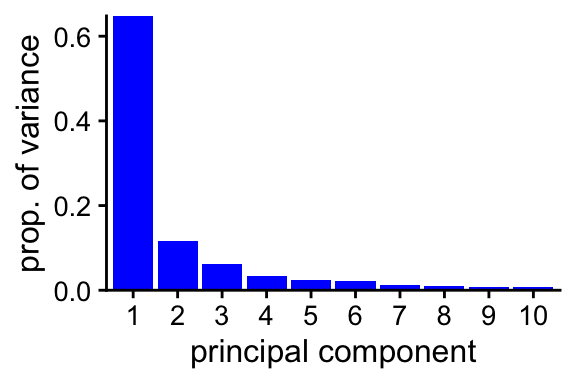

```r
plot_percentvar_rlog <-
  ggplot(data = propvar_rlog_df,
         aes(x = PC, y = prop_var)) +
  geom_col(fill = "blue") +
  scale_x_continuous("principal component",
                     limits = c(0.4,10.6),
                     # hack limits to include the bars and a little space.
                     breaks = 1L:10L,
                     expand = c(0,0)) +
  scale_y_continuous("prop. of variance", expand = c(0,0))
plot_percentvar_rlog
```

## Plot PC1 vs PC2 with default values

EDIT: the colour and other aesthetics may need to be edited to highlight features of the data

```r
ggplot(data = pcdf_rlog,
       aes(colour = interaction(Temperature,Media),
           shape = FLC1)
       ) +
  scale_shape_manual(values = c(2, 20)) +
  scale_colour_brewer("Temp., Media",
                      type = "qual", palette = 2) +
  geom_point(aes(x = PC1, y = PC2))
```

[output not shown]

## Plot PC1 vs PC2, 3, 4, also with default values

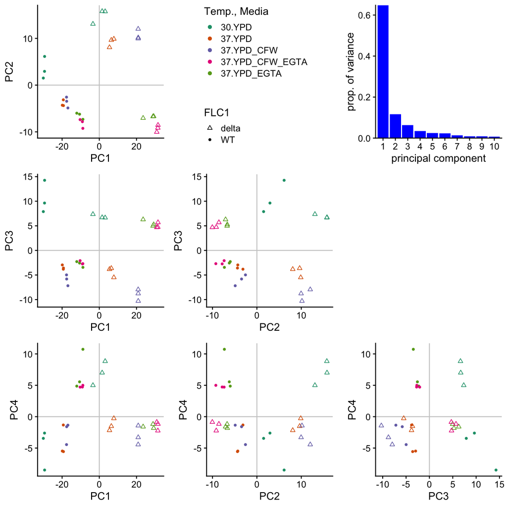

```r
# This could be wraped in a function
pc_baseplot <-
  ggplot(data = pcdf_rlog,
       aes(colour = interaction(Temperature,Media),
           shape = FLC1)
       ) +
  scale_shape_manual(values = c(2, 20)) +
  scale_colour_brewer("Temp., Media",
                      type = "qual", palette = 2) +
  geom_hline(yintercept = 0, size = 0.5, colour = "grey80") +
  geom_vline(xintercept = 0, size = 0.5, colour = "grey80") +
  theme(legend.position = "none")
pcplot_12 <- pc_baseplot + geom_point(aes(x = PC1, y = PC2))
pcplot_13 <- pc_baseplot + geom_point(aes(x = PC1, y = PC3))
pcplot_14 <- pc_baseplot + geom_point(aes(x = PC1, y = PC4))
pcplot_23 <- pc_baseplot + geom_point(aes(x = PC2, y = PC3))
pcplot_24 <- pc_baseplot + geom_point(aes(x = PC2, y = PC4))
pcplot_34 <- pc_baseplot + geom_point(aes(x = PC3, y = PC4))

pcplot_legend <- get_legend(pcplot_12 + theme(legend.position = "right", legend.margin = margin(t = 0, r = 0, b = 20, l = 40, unit = "pt")))
plot_grid(pcplot_12, pcplot_legend, plot_percentvar_rlog,
          pcplot_13, pcplot_23, NULL,
          pcplot_14, pcplot_24, pcplot_34,
          axis = "tblr", align = "hv")
```

# Session Info